# Random sampling of a normal distribution

Zhe Zhang

2016-06-07

**Introduction** This is a procedure that randomly generates a vector of *X* values following a normal distribution, with given mean and standard deviation.

# 1 Description

## 1.1 Project

Reporting of customized workflow (RoCA)

## 1.2 Analysis

This is a demo of the RoCA framework that generates random values with normal distribution.

# 2 Sampling

## 2.1 Summary statistics

**Table 1** Sampling results: expected vs. actual mean and standard deviation

|  | Length | Mean | Standard deviation |
| --- | --- | --- | --- |
| **Expected** | 1000 | 20 | 2 |
| **Actual** | 1000 | 19.986431 | 2.0358734 |

```
Summary statistics:
   Min. 1st Qu.  Median    Mean 3rd Qu.    Max.
  13.73   18.56   19.98   19.99   21.37   26.13

    Shapiro-Wilk normality test

data:  v
W = 0.9988, p-value = 0.7556
```

## 2.2 Plot distribution

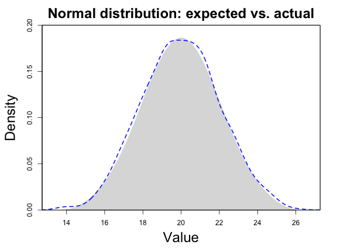

**Figure 1** This figure compares the expected data distribution with given mean and standard deviation (grey) and actual distribution of sampled data vector (blue line).

## 2.3 Outputs

The output folder, <**output**>, includes the following files:

- **sample_normal.Rmd**: The Rmarkdown file that generates this report
- **sample_normal.yml**: The Yaml configuration file that specifies this run
- **index.html**: The Html index file of this report
- **vector.rds**: The randomly generated values saved as an R vector
- **vector.csv**: The randomly generated values saved as text file

# 3 Appendix

Check out the **[RoCA home page](http://zhezhangsh.github.io/RoCA)** for more information.

## 3.1 Reproduce this report

To reproduce this report:

1. Find the data analysis template you want to use and an example of its pairing YAML file [here](https://github.com/zhezhangsh/RoCA/wiki/Templates-and-examples) and download the YAML example to your working directory
2. To generate a new report using your own input data and parameter, edit the following items in the YAML file:
   - *output* : where you want to put the output files
   - *home* : the URL if you have a home page for your project
   - *analyst* : your name
   - *description* : background information about your project, analysis, etc.
   - *input* : where are your input data, read instruction for preparing them
   - *parameter* : parameters for this analysis; read instruction about how to prepare input data
3. Run the code below within *R Console* or *RStudio*, preferablly with a new R session:

```r
if (!require(devtools)) { install.packages('devtools'); require(devtools); }
if (!require(RCurl)) { install.packages('RCurl'); require(RCurl); }
if (!require(RoCA)) { install_github('zhezhangsh/RoCAR'); require(RoCA); }

CreateReport(filename.yaml);  # filename.yaml is the YAML file you just downloaded and edited for your analysis
```

If there is no complaint, go to the *output* folder and open the *index.html* file to view report.

**END_OF_DOCUMENT**